# TP noté : Analyse de populations divergentes. Correction

Willy

November 22, 2018

# TP noté : Analyse de populations divergentes

## Introduction

```r
load('controle_struc.RData')
structRes0=tpdata[[7]]
```

## Description de la diversité génétique

1. Combien y a t il de positions polymorphes au locus 90 ?

```r
print(dim(structRes0$seg_sites[[90]]$snps)[2])
```

```
## [1] 1
```

2. Trouvez un locus ayant plus de 3 sites polymorphes et donnez le nombre d’haplotypes distincts pour ce locus.

```r
i <- 1
while (dim(structRes0$seg_sites[[i]]$snps)[2] < 4) {
  i <- i + 1
}

print(paste("the locus is: ", i, sep=""))
```

```
## [1] "the locus is: 4"
```

```r
nb_snps <- dim(structRes0$seg_sites[[i]]$snps)[2]
print(paste("the number of snps of locus", i, "is", nb_snps, sep=" "))
```

```
## [1] "the number of snps of locus 4 is 4"
```

```r
# Number of happlotypes of possition 1
hap <- apply(structRes0$seg_sites[[i]]$snps, 1, paste, collapse="")
print(paste("the number of happlotypes of position", i, "is", length(unique(hap)), sep=" "))
```

```
## [1] "the number of happlotypes of position 4 is 5"
```

```r
print(paste("the happlotypes are:", paste(unique(hap), collapse = " "), sep=" "))
```

```
## [1] "the happlotypes are: 1000 1001 0000 1010 1100"
```

3. Calculez l’estimateur de Watterson pour ce jeu de données.

```r
w <- rep(0, loc)
n <- 40 # number of haploid individuals (sample size)
c <- sum(1/(1:(n-1)))
for (i in 1:loc) {
  w[i] <- dim(structRes0$seg_sites[[i]]$snps)[2] / (L*c)

}
Est_W <- mean(w)
print(paste("Watterson estimation:", Est_W, sep = " "))
```

```
## [1] "Watterson estimation: 0.000578576489639891"
```

4. Est-il proche de ce que l’on attendrait pour une population non structurée de taille N ? Et de taille 2N ?

Nous avvons mis $\theta = 2*N*\mu$, donc la valeur trouvée devrait être proche de $2 * 10000 * 2 * 10^{-8} = 0.0004$

5. En utilisant la fonction computeFst.haps.coala écrite ce matin, calculez le Fst pour ce jeu de données.

```r
source("./compute_Fst.R")
Fst <- computeFst(structRes0$seg_sites, list(1:20, 21:40))
print(paste("The Fst value is:", Fst, sep = " "))
```

```
## [1] "The Fst value is: 0.215351314534909"
```

## Calcul alternatif du Fst

Un problème de la fonction *computeFst.haps.coala* est qu’elle est relativement lente. Ceci pourrait poser un problème dans la suite de l’exercice, car nous allons construire une approche ABC basée sur le $F_{ST}$ et nous aurons donc besoin de calculer cette statistique pour un très grand nombre d’échantillons simulés. On introduit donc la fonction ci-dessous, qui permet également de calculer le Fst mais avec un temps d’exécution plus court :

```r
computeFst.coala <- function(segsites, popList){
  D=0
  N=0
  nbSites <- length(segsites)
  nbSubPop <- length(popList)
  for(i in 1:nbSites){
    simloc=segsites[[i]]$snps
    if (length(simloc)>0){
      p=mean(simloc[,1])
      D=D+p*(1-p)
      Ntemp=0
      for (samplesIDs in popList){
        p2=mean(simloc[samplesIDs,1])
        Ntemp=Ntemp+(p2-p)^2
      }
      N=N+Ntemp/nbSubPop
    }
  }
  return(N/D)
}
```

Expliquez pourquoi cette fonction calcule bien le Fst. En particulier, expliquez quelle information est utilisée à chaque locus, et quelle définition du $_{ST}$ est utilisée.

*Réponse* La fonction utilise **seulement** l’information du premier snp pour chaqu’un des locus. La définition du $F_{ST}$ utilisée dans la fonction est : $F_{ST} = Var(p) / H_{T}$.

Calculez le $F_{ST}$ de votre échantillon à l’aide de cette fonction, et comparez avec le résultat obtenu précédemment.

```r
Fst_fast <- computeFst.coala(structRes0$seg_sites, list(1:20, 21:40))
print(paste("The new Fst value is:", Fst_fast, sep = " "))
```

```
## [1] "The new Fst value is: 0.260368381213278"
```

```r
print(Fst_fast - Fst)
```

```
## [1] 0.04501707
```

## Estimation ABC

Nous allons maintenant estimer $t$ par ABC en utilisant le $F_{ST}$ comme statistique résumante. Pour cela, nous allons simuler $1000$ échantillons semblables au nôtre, en tirant $t$ au hasard entre $0$ et $0.5$. Plutôt que de simuler tous les échantillons puis de calculer les $F_{ST}$ dans un second temps, nous allons simuler directement les $F_{ST}$ en utilisant l’argument tranformation de *sumstat_seg_sites()*. En effet, nous avons vu hier qu’on pouvait effectuer sur les sorties *sumstat_* de coala des transformation simples comme la somme et la moyenne, mais on peut aussi utiliser des transformations plus complexes décrites par des fonctions. Nous allons exploiter cette possibilité en insérant notre fonction calculant le $F_{ST}$. On commence par définir une fonction ayant comme seul argument l’attribut *seg_sites*, à savoir :

```r
computeFst.2pop_20ind <- function(segsites){
  computeFst.coala(segsites,list(1:20,21:40))
}
```

Puis on simule un échantillon pour un temps de divergence $t$ avec la commande :

```r
structModel <- coal_model(sample_size=c(20, 20), loci_number=loc, loci_length=L,ploidy=1) +
feat_mutation(rate=theta*L) + feat_pop_merge(t,2,1) +
sumstat_seg_sites(transformation=computeFst.2pop_20ind)
structRes0 <- simulate(structModel)
```

Au lieu de contenir la liste de tableaux habituelle, l’atribut *seg_sites* contient désormis le $F_{ST}$

```r
structRes0$seg_sites
```

```
## [1] 0.1775654
```

En vous inspirant de ce qui a été fait hier, complétez la fonction ci-dessous, qui simule des valeurs de $t$ et $F_{ST}$ pour le modèle de divergence considéré ici.

*Réponse*

```r
simul_div.2pop_20ind=function(loc,L,theta,nb_rep){
  # loc nombre de locus par échantillon
  # L taille de chaque locus (en paires de bases)
  # nb_rep nombre d'échantillons simulés
  # theta=2N*mu, mu taux de mutation par base
  # ...
  structModel <- coal_model(sample_size=c(20, 20), loci_number=loc, loci_length=L,ploidy=1) +
    feat_mutation(rate=theta*L) + feat_pop_merge(par_prior("t",runif(1, 0, 0.5)), 2, 1) +
    sumstat_seg_sites(transformation=computeFst.2pop_20ind)
  structRes <- simulate(structModel, nsim = nb_rep)
  t_vector <- rep(0, nb_rep)
  Fst_vector <- rep(0, nb_rep)
  for (i in 1:nb_rep) {
    t_vector[i] <- structRes[[i]]$pars[1]
    Fst_vector[i] <- structRes[[i]]$seg_sites

  }
  return(data.frame(t=t_vector, Fst=Fst_vector))
}
```

```r
# Simulating 1000 datasets
sim_results <- simul_div.2pop_20ind(loc, L, theta, 1000)
```

```r
# Apply the abc
library(abc)
```

```
## locfit 1.5-9.1    2013-03-22
```

```r
s <- Fst_fast
abc_param <- data.frame(t=sim_results$t)
abc_sumstat <- data.frame(Fst=sim_results$Fst)

abc_res <- abc(s, abc_param, abc_sumstat, tol=0.1, method="loclinear")

summary(abc_res,param=abc_param)
```

```
## Call:
## abc(target = s, param = abc_param, sumstat = abc_sumstat, tol = 0.1,
##     method = "loclinear")
## Data:
##  abc.out$adj.values (100 posterior samples)
## Weights:
##  abc.out$weights
##
##                             t
## Min.:                  0.2413
## Weighted 2.5 % Perc.:  0.2779
## Weighted Median:       0.3127
## Weighted Mean:         0.3130
## Weighted Mode:         0.3138
## Weighted 97.5 % Perc.: 0.3514
## Max.:                  0.3626
```

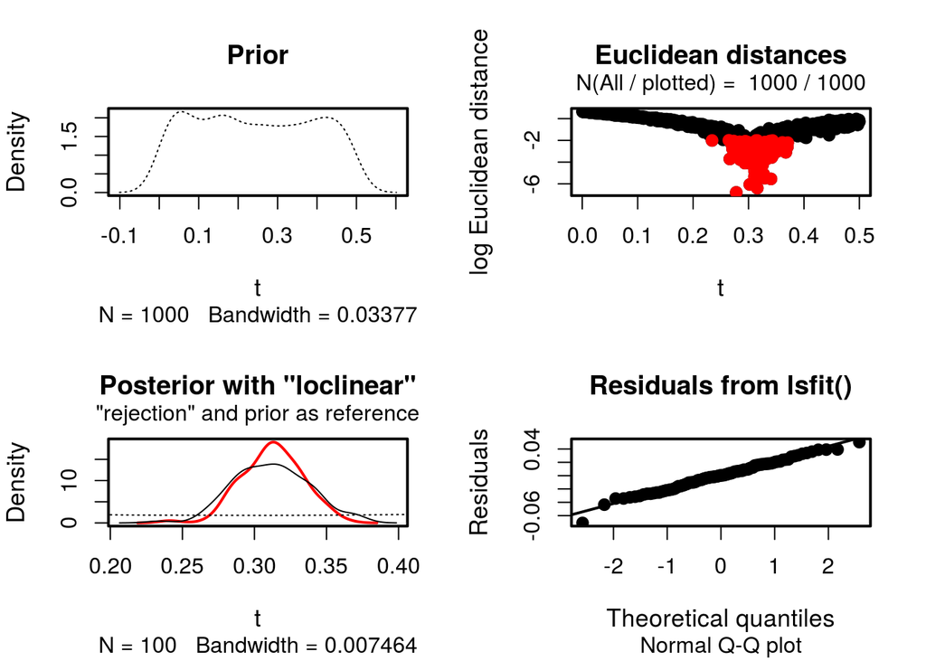

```r
plot(abc_res,abc_param)
```